# Irrelevant information

This plot shows one point per child. It indicates the probability, when given the possibility to query irrelevant information (arms when you already have a thrower, same for legs), that children select the irrelevant cue. Chance level is .5, anything above would be surprising. I would already start to recognize a trend that older kids (except one outlier) are quite disciplined about this. The size of the points indicates how many times this child was faced with the option of acquiring irrelevant information.

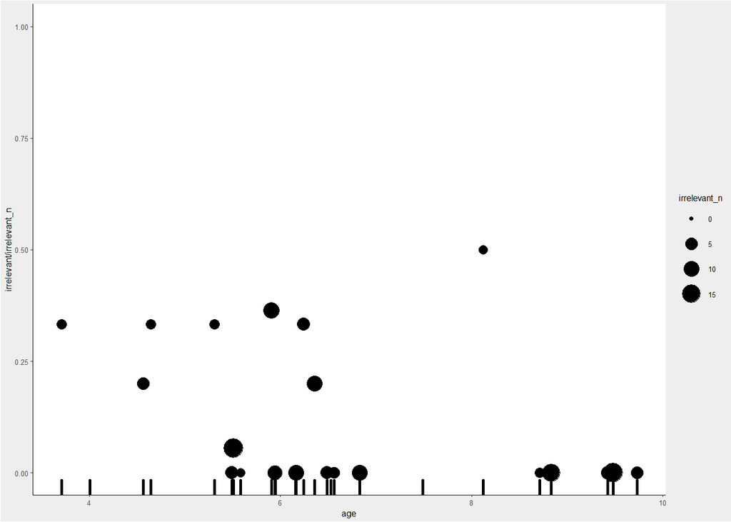

# Risky choices

In the Skewed Condition, long arms were rare. This plot shows how likely kids were in this condition to risk losing a valuable long-arm monster. This could be either by assigning a monster with unknown arms and long legs to the jumper slot, or discarding it while arms were unknown. Technically, it would also count as risky when arms were not only unkown but actually known to be long, but so far, when kids saw long arms, they all made no mistake in the skewed condition.

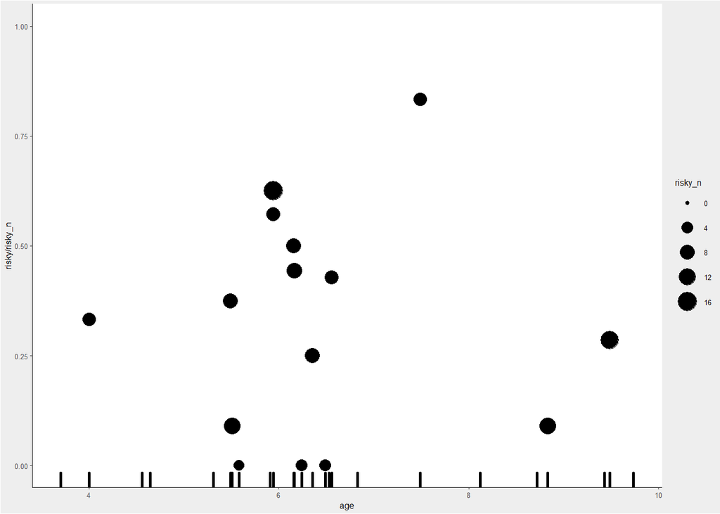

# Degrees of belief

The following two plots express the same data as posterior distributions of our degrees of belief about children’s probability to make an irrelevant or risky choice. For that, I put kids into 4 age groups and within each, I summed how often these kids were faced with an irrelevant-information or risk-of-losing-long-arms decision, and their responses to it.

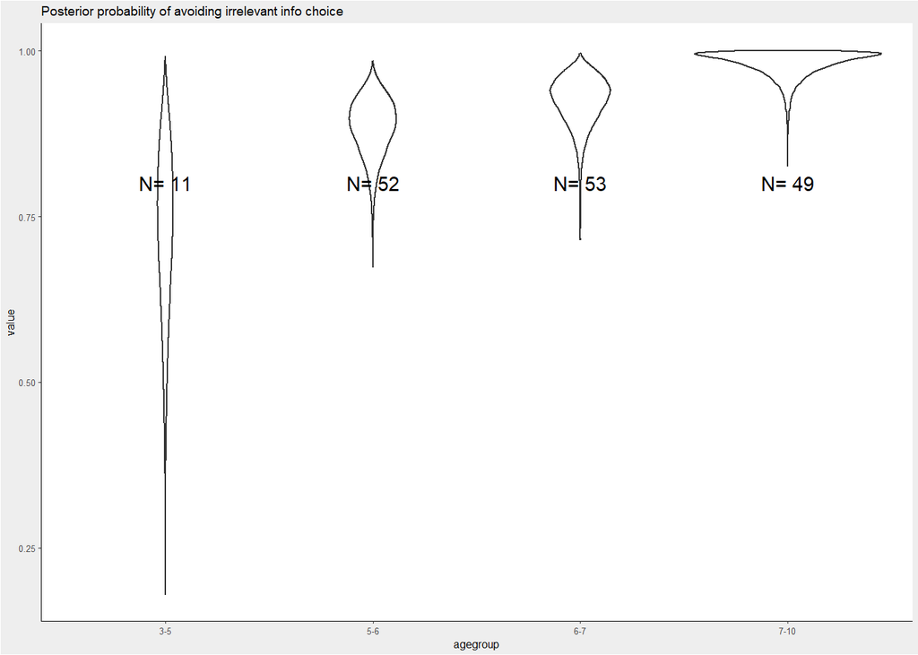

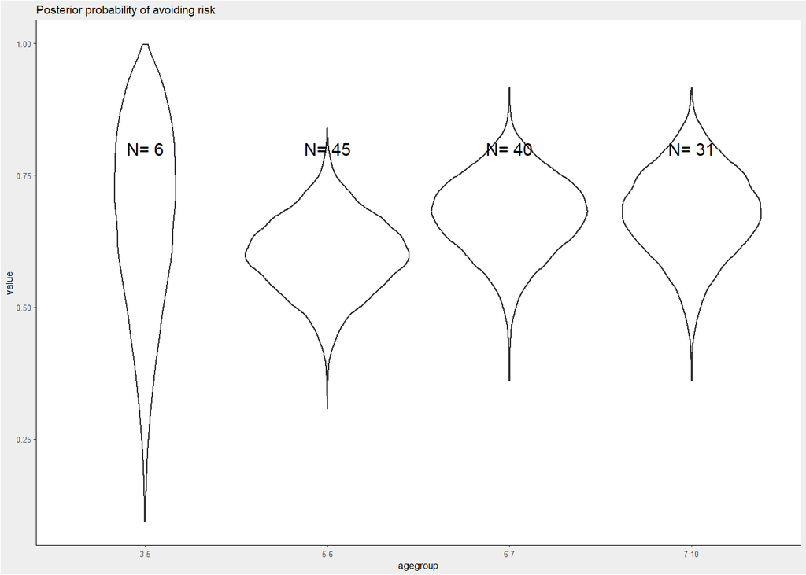

# First choice

```r
first_moves <- transcript %>%
  group_by(subject, condition) %>%
  summarize(first_move = move[1]) %>%
  mutate(correct_first = ifelse(condition == "skewed" & first_move == "qA", TRUE,
                                ifelse(condition == "even", NA, FALSE))) %>%
  left_join(subjects, by = "subject") %>%
  mutate(condition = condition.x) %>%
  select(-c(condition.x, condition.y, dob, date))

table(first_moves$correct_first)
```

```
##
## FALSE  TRUE
##     3    12
```